# R Notebook for Gulfstream generated dataset

# Overview of the dataset

We have two datasets which simulate the Sea Surface Height (SSH) and the Sea Surface Salinity (SSS) :

```r
library(ncdf4)
library(lattice)

nc <- nc_open("ref.nc", write=FALSE, readunlim=TRUE, verbose=FALSE,
        auto_GMT=TRUE, suppress_dimvals=FALSE )

print(nc)
```

```
## File ref.nc (NC_FORMAT_NETCDF4):
##
##      1 variables (excluding dimension variables):
##         double ssh[lon,lat,time]   (Chunking: [201,201,1])
##             _FillValue: NaN
##
##      3 dimensions:
##         time  Size:365   *** is unlimited ***
##             _FillValue: NaN
##             units: seconds since 2012-10-01 00:00:00
##         lat  Size:201
##             _FillValue: NaN
##         lon  Size:201
##             _FillValue: NaN
```

```r
NAT <- nc_open("NATL60.nc", write=FALSE, readunlim=TRUE, verbose=FALSE,
              auto_GMT=TRUE, suppress_dimvals=FALSE )
```

We extract the two arrays which are interesting for us

```r
ssh <- ncvar_get(nc,"ssh")
sss <- ncvar_get(NAT, "sss")
```

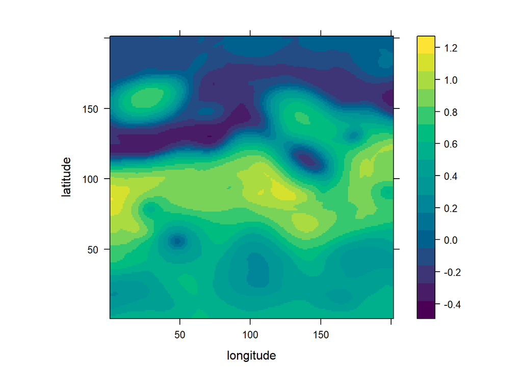

```r
levelplot(ssh[1:201,1:201,1],xlab="longitude",ylab="latitude",col.regions = hcl.colors(30))
```

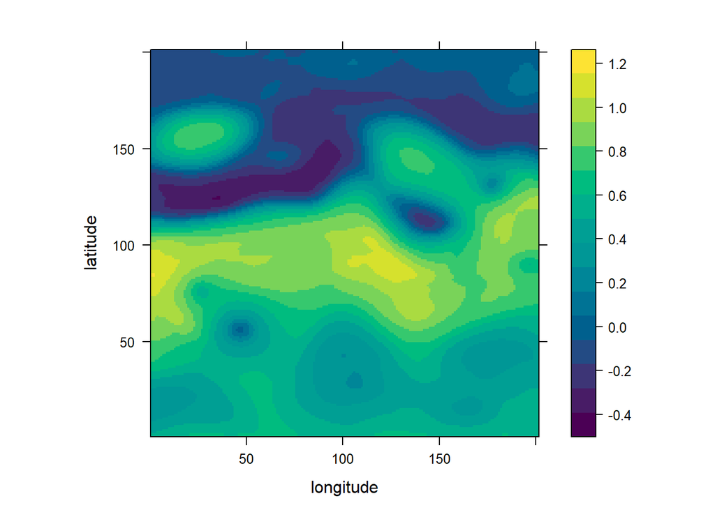

```r
levelplot(ssh[1:201,1:201,2],xlab="longitude",ylab="latitude",col.regions = hcl.colors(30))
```

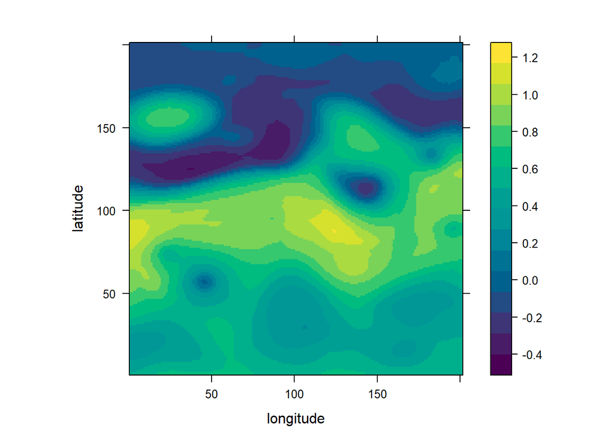

```r
levelplot(ssh[1:201,1:201,3],xlab="longitude",ylab="latitude",col.regions = hcl.colors(30))
```

We can divide the space in three distinct zone, namely the upper, the central and the lower zone. Each zone correspond to different magnitude of SSH.

For given latitude and longitude, we also plot the annual variation of the SSH :

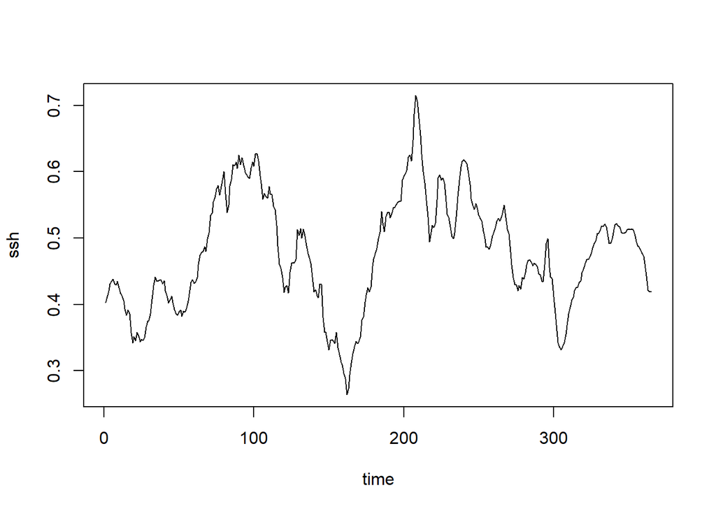

```r
lon<-150
lat<-20
plot(1:365, ssh[lon,lat,1:365], "line", xlab = "time", ylab="ssh")
```

We have to be careful that the day 1 is not the $1^{st}$ January but the $1^{st}$ October. For consistency we should divide the year within different periods (winter, summer …).

We create the corresponding dataset :

```r
gradssh <- array( dim = c(201,201,364))

for (i in 1:364){
  gradssh[,,i] <- ssh[,,i+1]-ssh[,,i]
}

lapssh <- array( dim = c(201,201,363))


for (i in 2:364){
  lapssh[,,i-1]<-ssh[,,i-1]+ssh[,,i+1]-2*ssh[,,i]
}
```

We’re now able to plot the gradient of the ssh for the first three days :

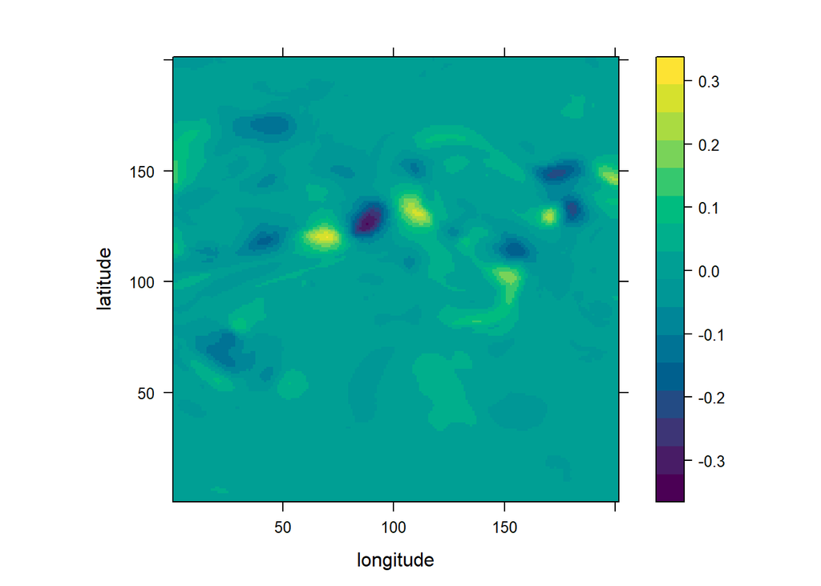

```r
levelplot(gradssh[1:201,1:201,1],xlab="longitude",ylab="latitude",col.regions = hcl.colors(30))
```

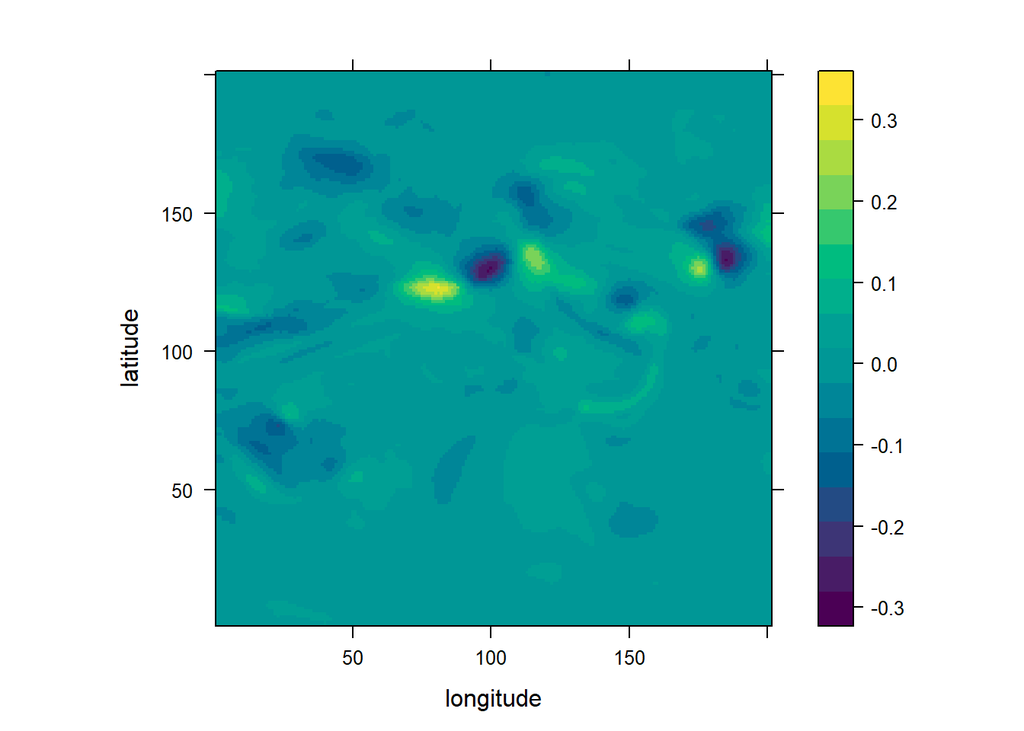

```r
levelplot(gradssh[1:201,1:201,2],xlab="longitude",ylab="latitude",col.regions = hcl.colors(30))
```

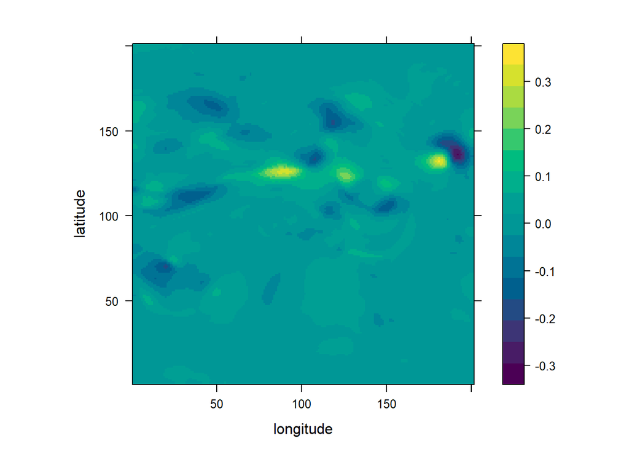

```r
levelplot(gradssh[1:201,1:201,3],xlab="longitude",ylab="latitude",col.regions = hcl.colors(30))
```

We can also plot the time variation of the gradient for a given location :

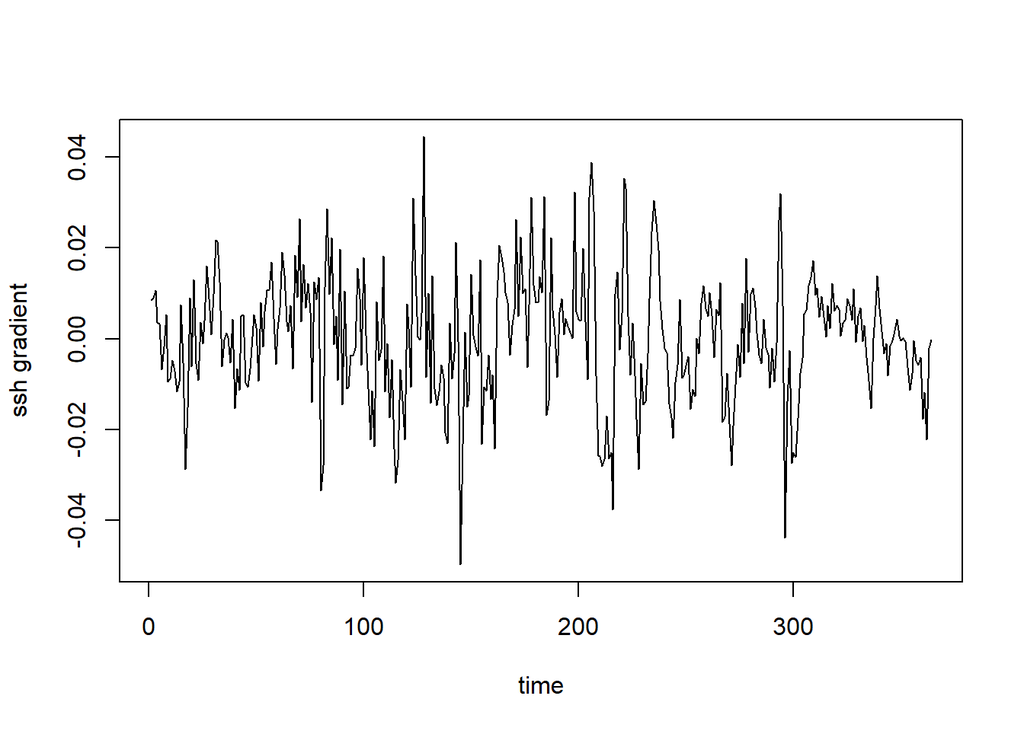

```r
plot(1:364,gradssh[lon,lat,1:364],"line", xlab = "time", ylab="ssh gradient")
```

# Modelling with GPD-Elliptical laws

A random variable $X$ of $\mathbb{R}^n$ is GPD-elliptical if its density is of the following type

$$f(x)= c_n g_{\sigma,\xi }((x-\mu)'\Sigma^{-1}(x-\mu))$$

with $\Sigma$ a definite positive matrix of $\mathbf{M}_{n\times n}$, $\mu$ a vector of $\mathbb{R}^n$, c a normalising constant and $g_{\sigma,\xi }$ a real-valued function of the form

$$g_{\sigma,\xi } (s) = ((1+\frac{\xi}{\sigma}s)^+)^{-\frac{1}{\xi}} \\
\sigma>0 \\
\xi<\frac{2}{n}$$
where $f^+$ denotes the positive part of $f$. We usually write

$$X\sim\epsilon_n(\mu,\Sigma,g_{\sigma,\xi })$$

It could also be reformulated in the following manner :

$$X = \mu + RA'U$$
with $A\in\mathbf{M}_{n\times n}$ such that $A'A=\Sigma$, $U\in\mathbb{R}^n$ uniformly distributed on the sphere unit and $R\in\mathbb{R^+}$, called the radial variable, independent from $U$ with density :

$$h(r) = \frac{2}{\int_{0}^{\infty} t^{\frac{n}{2}-1}g_{\sigma,\xi }(t) \, \mathrm{d}t}r^{n-1}g_{\sigma,\xi }(r^2)I_{[0,\infty[}(r)$$

In the univariate case, $n=1$ and $\Sigma\in\mathbb{R}_+^{*}$ and $A=\Sigma^{\frac{1}{2}}$. We focus on the univariate case when $R$’s support is bounded. It is equivalent to consider negative values for $\xi$. If $\xi<0$, $R$’s support is $[0,\sqrt{\frac{\sigma}{-\xi}}]$. The upper bound will be written $x_F$. Its cumulative distribution function,$H$, is :

$$H(r) = B(\frac{r^2}{x_F^2}\ ;\ \frac{1}{2},1-\frac{1}{\xi} )$$
where B stands for the incomplete Beta function.

We wish to get insight in the extreme behavior of GPD-elliptical variables.In particular we will pay specific attention to the behavior of $|X-\mu|$.

For a given real-valued $Y$, we will write that $Y\sim U\epsilon(x_F,\xi)$if its cumulative distribution function have the form of $H$ with parameters $\x_F$ and $\xi$. We can easily check that if $Y\sim U\epsilon(x_F,\xi)$ and $\alpha\in\mathbb{R}_+^{*}$, then $\alpha Y\sim U\epsilon(\alpha x_F,\xi)$.For any univariate GPD-elliptical random variable X, $|X-\mu|$ belongs to the family of $U\epsilon$. $\xi$ and $x_F$ have different impact on the extreme for a $U\epsilon$ variable.

$\xi$ stands for the frequency of apparition of extreme events.For a given $x_F$
$$\xi\longrightarrow-\infty\Rightarrow U\epsilon(x_F,\xi)\longrightarrow U_{[0,x_F]}\\
\xi\longrightarrow 0 \Rightarrow U\epsilon(x_F,\xi)\longrightarrow 0$$
$x_F$ is the upper bound of the distribution and could be viewed as the intensity of extremes.

## Examples

Let $X\sim\epsilon_n(\mu,\Sigma,g_{\sigma,\xi })$, $X = (X_1, X_2, ..., X_n)'$. As mentioned previously, we denote $x_F=\sqrt{\frac{\sigma}{-\xi}}$. We seek to characterize the differences in terms of extremes between the marginals $X_i$ and a given linear of the $X_i$ of the form :
$$Y=W'X\ ,\ W\in\mathbf{M}_{n\times 1}(\mathbb{R})$$
We keep focusing on the centered distribution, it is equivalent to set $\mu$ to $0$ without loss of generality. The marginals are then defined by :

$$|X_i|\sim U\epsilon(x_{F_i}\ ,\ \tilde{\xi})\\
x_{F_i}=(\Sigma_{i,i})^{\frac{1}{2}}x_F \\
\tilde{\xi} = \frac{\xi}{1-\alpha\xi} \quad , \quad \alpha=\frac{n-1}{2}$$

The linear combination of the $X_i$ is defined by :

### Case of a ponderated sum

Suppose $Y$ is a ponderated sum of $X_i$, and the $X_i$ iid. In this case, $\Sigma = aI_n$ with $a\in \mathbb{R}_+^*$. Because $Y$ is a ponderated sum of $X_i$, $W$’s elements are positive and sum to 1. We can easily infer that $x_{F_Y}=W'Wx_{F_i}$ and thus $x_{F_Y}\le x_{F_i}$. The upper bound is reduced.

### Case of the gradient

Let $X\sim\epsilon_n(\mu,\Sigma,g_{\sigma,\xi })$, $X = (X_1, X_2, ..., X_n)'$ with $x_F=\sqrt{\frac{\sigma}{-\xi}}$. We wish to compare the distribution of $\nabla_{t}$ and those of the marginals $X_t$ and $X_{t+1}$.We now that the vector $(\quad X_t \quad,\quad X_{t+1} \quad)'$ is GDP-elliptical.

The absolute values of the marginals are defined by :

$$|X_t|\sim U\epsilon(x_{F}(\Sigma_t)^{\frac{1}{2}}\ ,\ \tilde{\xi})\\$$
We have the following transformation :

$$\nabla_t = (\quad -1 \quad,\quad 1 \quad)(\quad X_t \quad,\quad X_{t+1} \quad)'$$
Thus,

$$|\nabla_t|\sim U\epsilon(x_{F}(\Sigma_t+\Sigma_{t+1}-2\theta)^{\frac{1}{2}}\ ,\ \tilde{\xi})$$
In the particular case of of i.i.d r.v, the upper bound is augmented by a factor $\sqrt2$.

#First attempt to model the gradient

We assume that, for a given location, the gradient have an univariate GPD-elliptical distribution.We plot hereafter the experimental cdf of the absolute value of the centered gradient

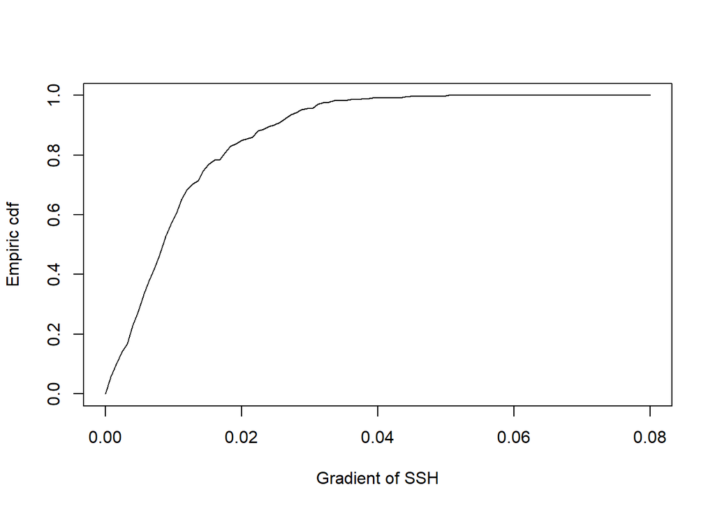

```r
# Fonction de répartition empirique

Femp<-function(vect,x){
  l=length(vect)
  return(sum(vect<x)/l)
}


Fempgrad<-(0:100)
for (i in 1:101){
  Fempgrad[i]<-Femp(abs(gradssh[lon,lat,1:364]-mean(gradssh[lon,lat,1:364])),((i-1)*0.0008))
}

plot(0.0008*(0:100),Fempgrad,"line", xlab="Gradient of SSH", ylab="Empiric cdf")
```

A first idea is to hand-tuned the value of $\xi$ and $\x_F$ to fit the empiric cdf.

```r
#cdf of univariate GPD-elliptical value

ksin<--0.015
xf<-0.07

H<-function(r){
  return(pbeta((r/xf)**2, 1/2,-1/ksin+1))
}

#Initialization of the parameters

xfmin<-xf
E<-sum((H((0:100)*0.0008)-Fempgrad)**2) #mean-square error
ksinmin<-ksin
k<-0

#Loop to refine the parameters

while (k<200){
  xfboucle<-xf
  for (b in 0:200){
    xf<-(xfboucle-0.01+b*0.0001)
    Enew<-sum((H((0:100)*0.0008)-Fempgrad)**2)
    if (Enew<E){
      xfmin<-xf
      E<-Enew
    }
  }
  xf<-xfmin
  for (j in 0.001*(1:1000)){
    ksin<--j
    Enew<-sum((H((0:100)*0.0008)-Fempgrad)**2)
    if (Enew<E){
      ksinmin<-ksin
      E<-Enew
    }
  }
  ksin<-ksinmin
  k<-k+1
}
  print(E)
```

```
## [1] 0.03064377
```

```r
  print(xf)
```

```
## [1] 0.0798
```

```r
  print(ksin)
```

```
## [1] -0.058
```

We can visualize the cdf found using this technique (in red), and compare it with the experimental cdf (in green):

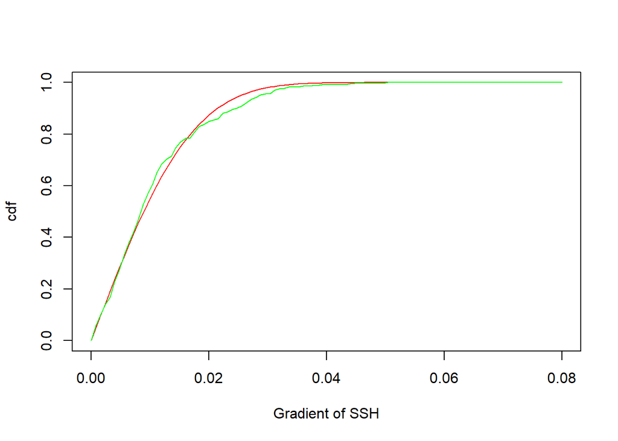

```r
plot(0.0008*(0:100),H((0:100)*0.0008),"line",col="red",xlab="Gradient of SSH", ylab="cdf")
points(0.0008*(0:100),Fempgrad,"line",col="green")
```

A major disadvantage is the high dependency between the initial condition and the convergence of the algorithm.

Another technique is to use the theoretical moments of such distribution. We can prove that, if $Z\sim U\epsilon(x_{F}\ ,\ \xi)$, then :
$$E(Z)=\frac{x_F}{(1-\frac{1}{\xi})B(\ \frac{1}{2}\ ,\ 1-\frac{1}{\xi} \ )}\\
\\
Var(Z)= x_F^2 \frac{\xi}{3\xi-2}$$
By using the estimators of mean and variance we could infer values for $x_F$ and $\xi$.